# R Graph Reference

Luisa M. Mimmi

Last run: September 29, 2019

## Set up

- I load the R scipt with my theme

```r
pacman::p_load(tidyverse, plyr, ggplot2, here, png)


# === save and source R script with `my_theme`
source(here::here("ggplot-theme.R"))

# (OR) # Define the theme locally
require(ggplot2)

my_theme <- theme(
    legend.position = "right",
    panel.background = element_rect(fill = NA),
    panel.border = element_rect(fill = NA, color = "grey75"), axis.ticks = element_line(color = "grey85"),
    panel.grid.major = element_line(color = "grey95", size = 0.2), panel.grid.minor = element_line(color = "grey95", size = 0.2), legend.key = element_blank())

# === To USE: simply add to plot `+ my_theme`
```

### Reproducing small R object (NYE anonimized stuff )

```r
# I had save the file as ASCII object before
        #dput(Don_byType, file = "Don_byType.text")

# Read it back here
NYEtest <- dget(here::here(  "Don_byType.text"))
```

## Multiple line graph + facet_wrap

- wide to long df
- (all gathered vars must have same type)
- show point + line

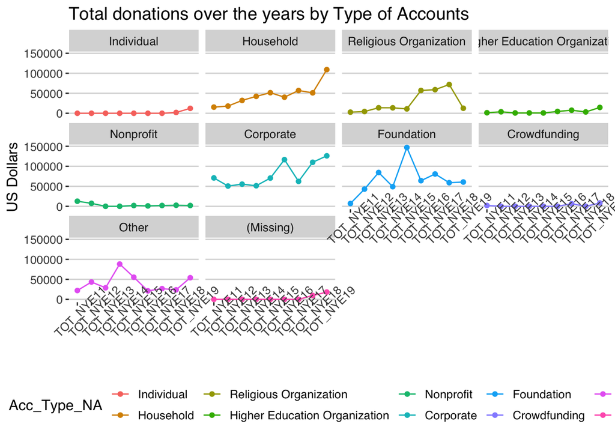

```r
# ---- wide to  Long format
ByTypeTOT_Long <- NYEtest %>%
    select(1, 3:11)  %>%
    # I have t reconvert back to numeric or error
    # ... attributes are not identical across measure variables;they will be dropped
    # mutate_each(list(~as.numeric), contains('TOT_')) %>%
    gather(key= "NYE_Edition" , value = "USDollars",
             'TOT_NYE11', 'TOT_NYE12', 'TOT_NYE13', 'TOT_NYE14', 'TOT_NYE15',
             'TOT_NYE16', 'TOT_NYE17', 'TOT_NYE18','TOT_NYE19',
              na.rm = FALSE)

# ---- plot
plot <- ggplot(ByTypeTOT_Long) +
    aes(x = NYE_Edition,  y = USDollars,  color = Acc_Type_NA) +
    geom_point() +
    geom_line(aes(group = Acc_Type_NA))  +
    labs(title="Total donations over the years by Type of Accounts",
          x =NULL, y = "US Dollars") +
    ggthemes::theme_hc() + #+ scale_colour_hc()# theme_urban() +
    theme(axis.text.x = element_text(angle=45) ) +  ##  theme(text=element_text(family="Garamond", size=14))
    facet_wrap((~ Acc_Type_NA))

plot
```

## Count of element in Sample By 2 categorical variables: {1) Law Stack 2) rango-size }

- dataset in wide form
- `DON'T MAP A VARIABLE TO Y`
- shows counts of obs by level of one var, by class of another var

```r
# -----  { Count of obs in sample by 2 categorical variables: 1) Law Stack 2) rango-size }
ggplot(data = Bra1_complete) +
    geom_bar() + #   position = "dodge",width=0.7) +
    aes(x = Q8a_c_Leg_comb) +
    aes(fill = Cov_pop_rango_lbl) +
    # scale_fill_discrete(name = "Size of population \ncovered") +
    scale_fill_manual(values = colorRampPalette(RColorBrewer::brewer.pal(9, "Purples"))(8)[0:8],
                            na.value="grey", guide = guide_legend(reverse = F)) +
    labs(fill = "Size of population \ncovered") +

    labs(x = "") +
    labs(y = "Count of Suppliers in Sample") +
    labs(title = "Number of WSS suppliers in Brazil sample by existing legislation
          \n(Coverage + Service + Quality + Tariffs) and Size of covered area") +
    coord_flip()  +
    my_theme -> p2
p2
#ggsave(p2, filename=here::here("07_output", "Plot_CountByRango.png"))
```

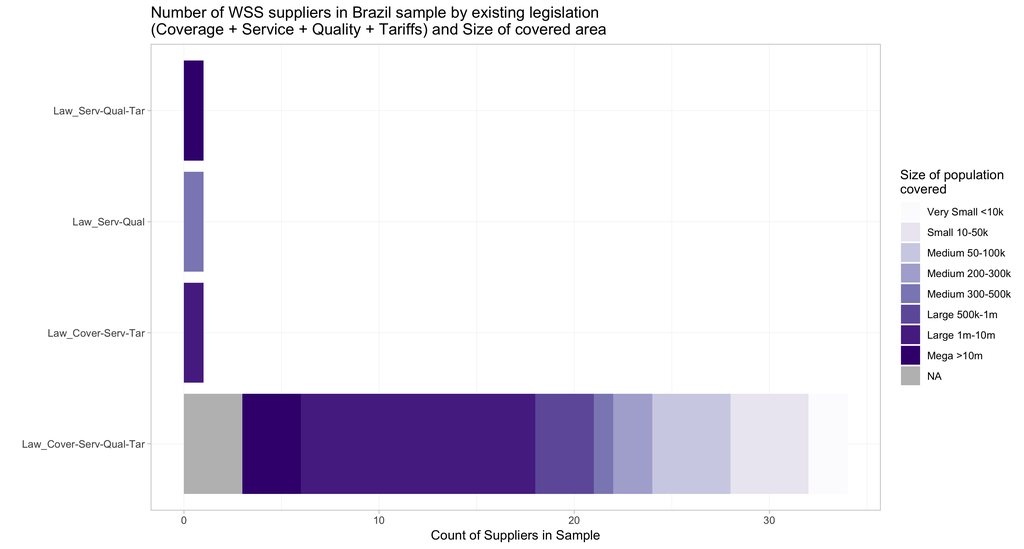

Count By LawStack and Rango

```r
# -----  Doesn't work (dir issue)
img2_path <- here::here( "Plot_CountByRango.png")
library(png)
img2 <- readPNG(img2_path, native = TRUE, info = TRUE)
# attr(img1, "info")

# -----  Doesn't work (dir issue)
# knitr::include_graphics(img1_path)
```

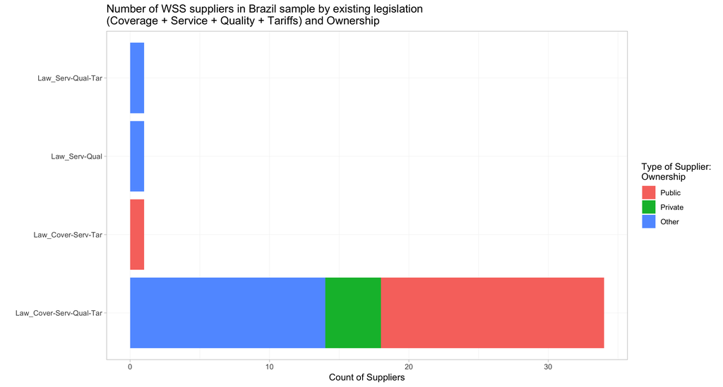

Count By LawStack and Ownership

```r
# similar
ggplot(data = Bra1_complete) +
    aes(x = Q8a_c_Leg_comb) +
    aes(fill = Q1_ownership_lbl) +
    geom_bar() +
    labs(fill = "Type of Supplier: \nOwnership") +
    labs(x = "") +
    labs(y = "Count of Suppliers") +
    labs(title = "Number of WSS suppliers in Brazil sample by existing legislation
          \n(Coverage + Service + Quality + Tariffs) and Ownership") +
    coord_flip()  + my_theme -> p

p
# save plot
ggsave(p, filename=here::here("07_output", "Plot_CountByLawOwnersh.png"))
```

## Density plot of 1 continuous {VAR NRWm3_pct} BY 1 categorical variables: {Q1_ownership_lbl}

- dataset in wide form
- Using `plyr::ddply` –> Split data frame, apply function, and return results in a data frame (similar to `dplyr::group__map()_by %>% summarise` to iterate on groups)
- `ggplot2::geom_density` + `ggplot2::geom_vline`

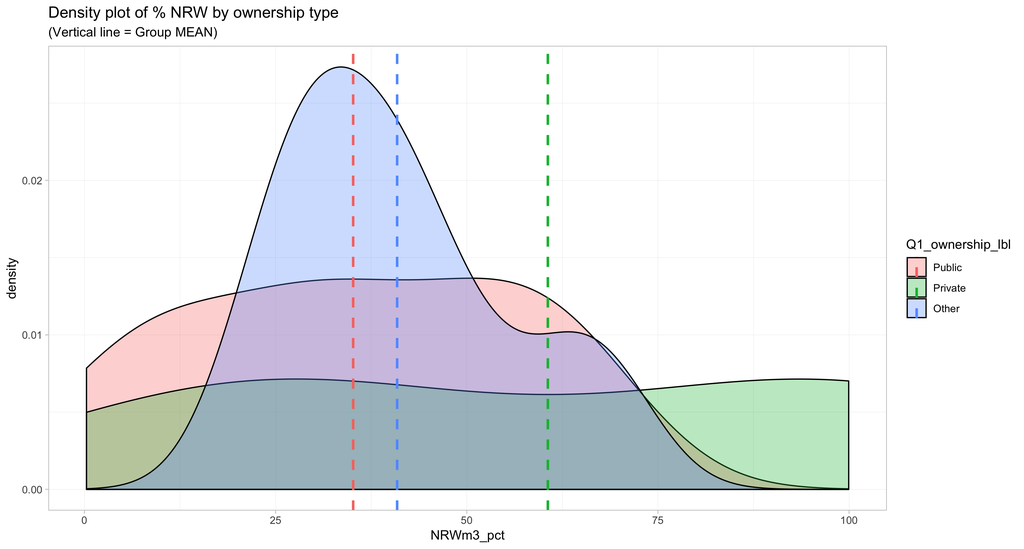

Density of NRW By Ownership

```r
library(plyr)

# ----- find the mean for each group
densNWR <- Bra1_complete %>%
    # Get rid of NA in NRW
    drop_na(., NRWm3_pct) %>%
    # return mean by group
    plyr::ddply(., # data
                    "Q1_ownership_lbl", # var
                    summarise, NRWm3_pct.mean=mean(NRWm3_pct), NRWm3_pct.med=median(NRWm3_pct) # function
                    )

# ----- Plot
ggplot (    data = Bra1_complete , aes ( x=NRWm3_pct, fill = Q1_ownership_lbl )) +
    geom_density(alpha=.3) +
    geom_vline(data=densNWR, aes(xintercept= NRWm3_pct.mean,  colour=Q1_ownership_lbl),
                  linetype="dashed", size=1, show.legend = T)  +
    labs(title = "Density plot of % NRW by ownership type",
          subtitle = "(Vertical line = Group MEAN)") +
    my_theme ->  NRWp

NRWp

# ----- Save plot
ggsave(NRWp, filename=here::here("07_output", "Plot_DensNRW_byOwn.png"))
```

## Density plot of 1 continuous VAR {NRWm3_pct} BY 1 categorical variables (faceted): {Cov_pop_rango_lbl}

- (same as above), but…
- `ggplot2::facet_wrap`

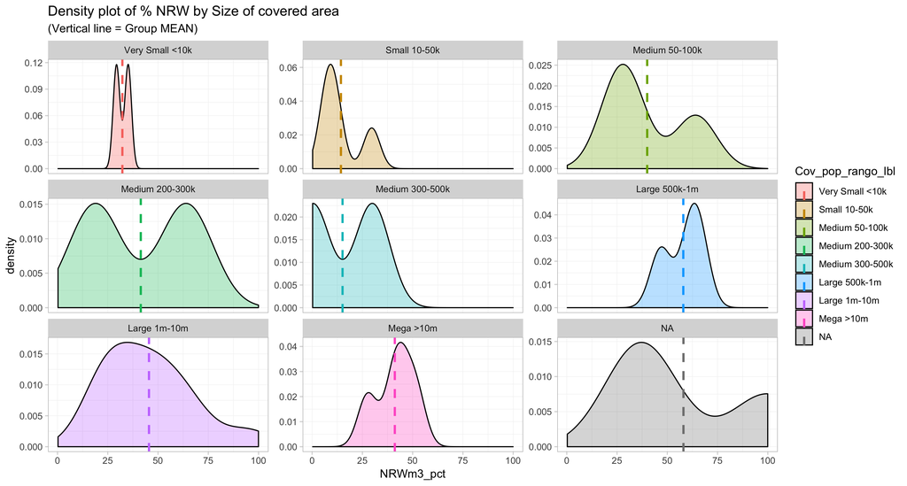

Density of NRW By Size

```r
library(plyr)
# BY  Q9a_d_Mix_comb /  Cov_pop_rango_lbl

# ----- find the mean for each group
densSIZE <- Bra1_complete %>%
    # Get rid of NA in NRW
    drop_na(., NRWm3_pct) %>%
    plyr::ddply(., "Cov_pop_rango_lbl", summarise,
                    NRWm3_pct.mean=mean(NRWm3_pct) , NRWm3_pct.med=median(NRWm3_pct))
densSIZE

# -----Plot
ggplot (    data = Bra1_complete , aes ( x=NRWm3_pct, fill = Cov_pop_rango_lbl )) +
    geom_density(alpha=.3) +
    geom_vline(data=densSIZE, aes(xintercept= NRWm3_pct.mean,  colour=Cov_pop_rango_lbl),
                  linetype="dashed", size=1, show.legend = T)  +
    labs(title = "Density plot of % NRW by Size of covered area",
          subtitle = "(Vertical line = Group MEAN)") +
    facet_wrap(~ Cov_pop_rango_lbl, scales = "free_y") +
    my_theme ->  SIZEp

# ----- see plot
SIZEp
# ----- save plot
ggsave(SIZEp, filename=here::here("07_output", "Plot_DensNRW_bySIZE.png"))
```

> Using functions to repeat charts follow https://rpubs.com/alexbra/173596 !!!!!!

## DOTPLOT {2 cont variables & BY (color) 1 categ var}

- design a function that I can reuse (changing variables, labels, title)
- call the function

[figure not shown]

Dot Plot of NRW By ServMix and Perc Meters

```r
# ----- Create function for scatterplot object
point_plot_func <- function(factor, x_str, y_str, xl, yl, t, rvrs = T,lt = "Factor levels" ){
    # I declaring the dataset inside for the project
    ggplot( data = Bra1_complete, aes_string(x=x_str, y = y_str, color=factor)) +
        geom_point(size=3, alpha=0.5, position="jitter") +
        xlab(xl)+
        ylab(yl)+
        ggtitle(t)+
        scale_color_brewer(palette="Spectral",
                                 guide = guide_legend(title = lt, reverse = rvrs)) +
        my_theme
}


# ----- call Func: NRWm3_pct x Q27_IndivMeter_Perc BY Q9a_d_Mix_comb
dot1 <- point_plot_func(factor = "Q9a_d_Mix_comb",
                      x_str = "Q27_IndivMeter_Perc",
                      y_str = "NRWm3_pct",
                      xl = "Perc Conn with Indiv Meter",
                      yl = "Percent NRW",
                      t = "", # no title, I am using caption in md
                      rvrs = F)+
    coord_cartesian(ylim=c(0,100)) +
    geom_rect(aes(xmin=0,xmax=Inf,ymin=50,ymax=Inf), alpha=0.005,fill="red", linetype="blank")

# ----- save
ggsave(dot1, filename=here::here("07_output", "Plot_DotsNWR_Meter_byMIX.png"))
```

## BOXPLOT could do the same but {1 cont variable & 1 categ Variable }

- design a function that I can reuse (changing variables, labels, title)
- call the function

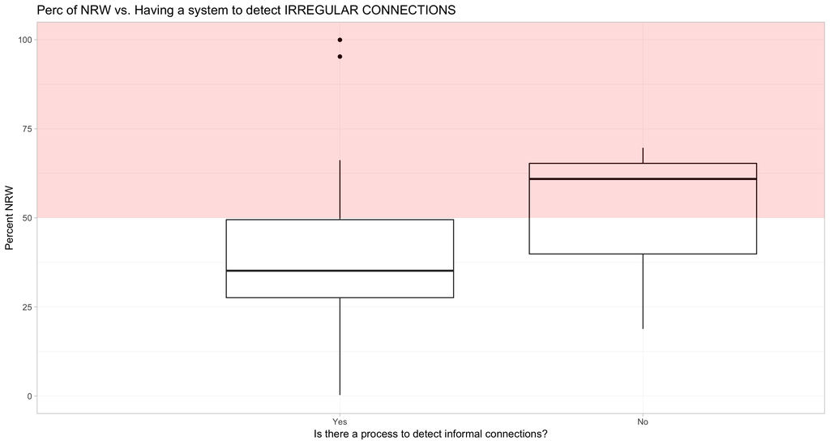

Box plot of NRW By Perc clandest

```r
# -----function to create box plot object
box_plot_func <- function(factor,
                                  lt = "Factor levels",
                                  x_str = "quality.rank",
                                  y_str,
                                  xl = "Quality rank",
                                  yl,
                                  t){
    ggplot(data = Bra1_complete, aes_string(x=x_str, y = y_str, color=factor)) +
        geom_boxplot() +
        xlab(xl) +
        ylab(yl) +
        ggtitle(t) +
        my_theme
}

# -----call Func :   NRWm3_pct BY Q41_ClandConn_Analyzed
box_plot_func(factor = NULL,
                    x_str = "Q41_ClandConn_Analyzed",
                    y_str = "NRWm3_pct",
                    xl = "Is there a process to detect informal connections?",
                    yl = "Percent NRW",
                    t = "Perc of NRW vs. Having a system to detect IRREGULAR CONNECTIONS") +
    coord_cartesian(ylim=c(0,100)) +
    geom_rect(aes(xmin=0,xmax=Inf,ymin=50,ymax=Inf), alpha=0.005,fill="red", linetype="blank") -> box1

# -----save
ggsave(box1, filename=here::here("07_output", "Plot_BOXNWR_Cland.png"))
```

## BARPLOT of Count of obs BY 1 grouped var & By (color) 1 categ Variable

- wide to long
- design a function that I can reuse (changing variables, labels, title)
- call the function

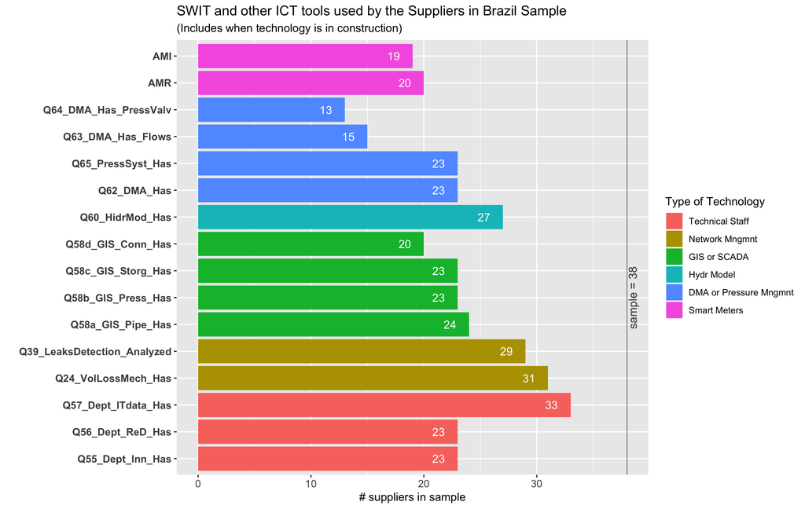

Bar Plot for # of obs adopting SWIT by Type

```r
# -----wide to long --> gather variables about SWIT
SWIT_long <- Bra1_compl_SWIT %>%
    # wide to long (omly on specified selected var )
    tidyr::gather(.,key = "technology" , value = "value",
                      # specific vars I want to gather
                      VolLossEstim =  Q24_VolLossMech_Has,
                      LeaksDetection  = Q39_LeaksDetection_Analyzed,
                      Dept_Innov= Q55_Dept_Inn_Has,
                      Dept_R_D = Q56_Dept_ReD_Has ,
                      Dept_IT_data= Q57_Dept_ITdata_Has ,
                      GIS_Pipes= Q58a_GIS_Pipe_Has ,
                      GIS_PressValves= Q58b_GIS_Press_Has,
                      GIS_Reserv= Q58c_GIS_Storg_Has ,
                      GIS_ConnPts = Q58d_GIS_Conn_Has ,
                      HidrMod   = Q60_HidrMod_Has ,
                      DMA   = Q62_DMA_Has   ,
                      DMA_w_flows   = Q63_DMA_Has_Flows   ,
                      DMA_w_pressvalves = Q64_DMA_Has_PressValv   ,
                      PressSyst= Q65_PressSyst_Has,
                      AMR  ,
                      AMI) %>%
    # I turn value from "Yes/No/DK" to DUMMY 0/1
    dplyr::mutate(value_dummy = case_when(value == "Yes" ~ 1,
                                                      value == "InConstr" ~ 1,
                                                      value == "No" ~ 0,
                                                      value == "DK" ~ 0,
                                                      value == "na" ~ 0))


# ----- GROUP BY & COUNT obs each group
SWIT_long2 <- SWIT_long %>%
    dplyr::group_by(technology) %>%
    dplyr::summarise(Count_SWIT = sum( value_dummy)) %>%
# ----- add technology category var
    dplyr::mutate( tech_type = case_when(
        technology ==   "Q55_Dept_Inn_Has" | technology ==  "Q56_Dept_ReD_Has" | technology ==   "Q57_Dept_ITdata_Has" ~ 1,
        technology ==   "Q24_VolLossMech_Has"| technology == "Q39_LeaksDetection_Analyzed" ~ 2 ,
        technology == "Q68_SCADA_UtilLevel" | technology == "Q58a_GIS_Pipe_Has" |
        technology == "Q58b_GIS_Press_Has"| technology =="Q58c_GIS_Storg_Has" |
        technology =="Q58d_GIS_Conn_Has" ~ 3,
        technology ==    "Q60_HidrMod_Has"   ~ 4,
        technology == "Q62_DMA_Has" |technology == "Q65_PressSyst_Has"
        |technology ==  "Q63_DMA_Has_Flows" |technology == "Q64_DMA_Has_PressValv"      ~ 5,
        technology ==  "AMR"  | technology =="AMI"~ 6)
        )


# ----- Define the order I want for technology category vars
SWIT_long2$technology <-factor(SWIT_long2$technology,
                                         levels = c("Q55_Dept_Inn_Has", "Q56_Dept_ReD_Has", "Q57_Dept_ITdata_Has",
                                                      "Q24_VolLossMech_Has",  "Q39_LeaksDetection_Analyzed",
                                                      "Q68_SCADA_UtilLevel" ,  "Q58a_GIS_Pipe_Has" ,
                                                      "Q58b_GIS_Press_Has", "Q58c_GIS_Storg_Has",
                                                      "Q58d_GIS_Conn_Has" , "Q60_HidrMod_Has" , "Q62_DMA_Has" ,
                                                      "Q65_PressSyst_Has" , "Q63_DMA_Has_Flows" ,
                                                      "Q64_DMA_Has_PressValv", "AMR"  , "AMI" ))

SWIT_long2$tech_type <-factor(SWIT_long2$tech_type,
                                        levels = c("1", "2","3" ,"4" ,"5" ,"6" ), # order
                                        labels = c("Technical Staff", "Network Mngmnt","GIS or SCADA" ,"Hydr Model",
                                                      "DMA or Pressure Mngmnt" ,"Smart Meters" )
)

# ----- PLOT
ggplot(SWIT_long2) +
    aes(x = technology, y = Count_SWIT , fill = tech_type)  +
    geom_bar(stat = "identity", position="identity") +
    # count inside bars
    geom_text(aes(label=Count_SWIT), color = "white", hjust=2)+
    theme( axis.text.x = element_text(size=10), axis.text.y = element_text(size=10,face="bold") ) + # they are flipped!!!
    labs(title="SWIT and other ICT tools used by the Suppliers in Brazil Sample" ,
          subtitle = "(Includes when technology is in construction)") +
    labs(x = "", y = "# suppliers in sample" ) +
    # rename legend labels
    guides(fill=guide_legend(title="Type of Technology")) +
    # reference line to show tot N of sample
    geom_hline(yintercept=38, color = "#616161", size=0.3) +
    geom_text(aes(x= 7, label="sample = 38", y=38), colour="#616161", angle=90, vjust = 1.2 ) +
    coord_flip()        -> ggSWITbar

# ----- save
ggSWITbar
ggsave( ggSWITbar, filename =here::here("07_output", "ggSWITbar.png"))
```